# K-fold Factor Analysis - Baseline

October 30, 2022

# Overview

**# of folds:** 2

**# of variables:** 21

**# of observations:** 354

**Maximum # of factors:**

- Allowed - 6
- Extracted - 3

**Estimation:** ML

**Missing Data:** listwise

# Model Summary

**Fit across folds by factor model**

| model | df.scaled | chisq.scaled mean | chisq.scaled range | cfi.scaled mean | cfi.scaled range | rmsea.scaled mean | rmsea.scaled range |
| --- | --- | --- | --- | --- | --- | --- | --- |
| 1-factor | 37.54877 | 76.95 | 68.75 - 85.14 | 0.51 | 0.43 - 0.60 | 0.08 | 0.06 - 0.09 |
| 2-factor | 41.20371 | 56.76 | 43.88 - 69.64 | 0.78 | 0.64 - 0.92 | 0.04 | 0.02 - 0.06 |
| 3-factor | 42.95187 | 59.13 | 59.13 - 59.13 | 0.79 | 0.79 - 0.79 | 0.05 | 0.05 - 0.05 |

**Count of folds out of 2 with flagged problems**

| model | mode structure | improper solution | heywood item | low loading | high factor correlation | low scale reliability |
| --- | --- | --- | --- | --- | --- | --- |
| 1-factor | 2 | 0 | 0 | 2 |  | 0 |
| 2-factor | 2 | 0 | 0 | 1 | 0 | 1 |
| 3-factor | 1 | 0 | 0 | 0 | 0 | 0 |

*Notes:*  
‘mode structure’ is the number of folds the EFA identified the mode (most common) structure. This structure was then used in the CFA. ‘mode structure’ will be 2 when the same structure was identified in every fold and < 2 when multiple factor structures were identified. The value in ‘mode structure’ is the maximum value for all remaining columns. See Appendix for all structures.  
‘improper solution’ is the number of folds with non-convergence or a non-positive definite matrix.  
‘high factor correlation’ threshold set to 0.9.  
‘low scale reliability’ threshold set to 0.6 with $\omega_h$.  
‘low loading’ threshold set to 0.3.  
blanks = not applicable

# Model Details

## 1-factor

**Factor Structure**

f1 =~ capable_person_b + confident_abt_future_b + comfortable_who_i_am_b + feel_smart_b + respect_lookup_b + worried_other_think_b + belong_school_b + people_accept_b + comfortable_at_school_b + worry_abt_dumb_b + nervous_worried_b + worry_ppl_dislike_b + conclusion_other_deaf_b + conclusion_my_perform_b + conclusion_abt_me_b + bad_grades_b + not_understand_class_b + not_understand_homework_b + bad_class_teacher_b + trouble_studying_b + pressure_parent_teacher_b

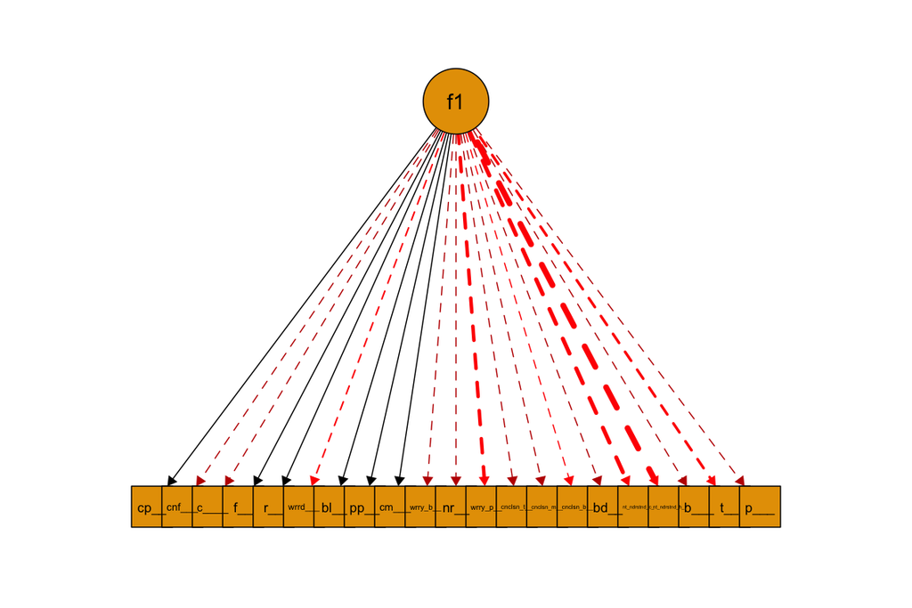

**Standardized Loading Across Folds**

| variable | mean | range | loading flag | heywood flag |
| --- | --- | --- | --- | --- |
| capable_person_b | 0.19 | 0.12 - 0.25 | 2 | 0 |
| confident_abt_future_b | -0.11 | -0.13 - -0.08 | 2 | 0 |
| comfortable_who_i_am_b | 0.08 | -0.02 - 0.17 | 2 | 0 |
| feel_smart_b | 0.12 | 0.04 - 0.20 | 2 | 0 |
| respect_lookup_b | 0.15 | 0.10 - 0.21 | 2 | 0 |
| worried_other_think_b | -0.48 | -0.53 - -0.43 | 2 | 0 |
| belong_school_b | 0.06 | 0.03 - 0.10 | 2 | 0 |
| people_accept_b | 0.15 | 0.09 - 0.20 | 2 | 0 |
| comfortable_at_school_b | 0.06 | 0.03 - 0.10 | 2 | 0 |
| worry_abt_dumb_b | -0.52 | -0.56 - -0.49 | 2 | 0 |
| nervous_worried_b | -0.45 | -0.48 - -0.42 | 2 | 0 |
| worry_ppl_dislike_b | -0.58 | -0.58 - -0.58 | 2 | 0 |
| conclusion_other_deaf_b | -0.43 | -0.51 - -0.35 | 2 | 0 |
| conclusion_my_perform_b | -0.42 | -0.43 - -0.41 | 2 | 0 |
| conclusion_abt_me_b | -0.51 | -0.52 - -0.51 | 2 | 0 |
| bad_grades_b | -0.47 | -0.47 - -0.47 | 2 | 0 |
| not_understand_class_b | -0.56 | -0.59 - -0.53 | 2 | 0 |
| not_understand_homework_b | -0.55 | -0.63 - -0.47 | 2 | 0 |
| bad_class_teacher_b | -0.44 | -0.49 - -0.39 | 2 | 0 |
| trouble_studying_b | -0.50 | -0.56 - -0.45 | 2 | 0 |
| pressure_parent_teacher_b | -0.44 | -0.51 - -0.37 | 2 | 0 |

Note: loadings flagged when < 0.3 in a fold. ‘heywood flag’ is the number of folds the variable’s estimated residual variance was negative

**Scale Reliability Across Folds**

| factor | omega_h mean | omega_h range | omega_h flag | alpha mean | alpha range | alpha flag |
| --- | --- | --- | --- | --- | --- | --- |
| f1 | 0.73 | 0.70 - 0.75 | 0 | 0.63 | 0.62 - 0.63 | 0 |

Note: ‘flag’ is the number of folds the scale had a reliability < 0.6

## 2-factor

**Factor Structure**

f1 =~ capable_person_b + confident_abt_future_b + comfortable_who_i_am_b + feel_smart_b + respect_lookup_b + belong_school_b + people_accept_b + comfortable_at_school_b

f2 =~ worried_other_think_b + worry_abt_dumb_b + nervous_worried_b + worry_ppl_dislike_b + conclusion_other_deaf_b + conclusion_my_perform_b + conclusion_abt_me_b + bad_grades_b + not_understand_class_b + not_understand_homework_b + bad_class_teacher_b + trouble_studying_b + pressure_parent_teacher_b

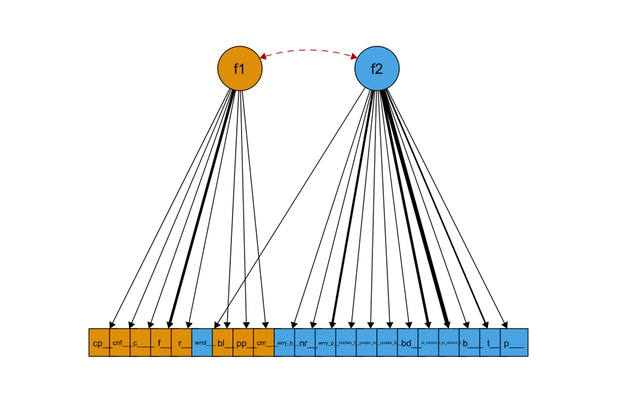

**Standardized Loading Across Folds**

| variable | mean | range | loading flag | heywood flag |
| --- | --- | --- | --- | --- |
| capable_person_b | 0.35 | 0.31 - 0.39 | 0 | 0 |
| confident_abt_future_b | 0.26 | 0.21 - 0.31 | 1 | 0 |
| comfortable_who_i_am_b | 0.48 | 0.47 - 0.50 | 0 | 0 |
| feel_smart_b | 0.54 | 0.49 - 0.59 | 0 | 0 |
| respect_lookup_b | 0.38 | 0.38 - 0.39 | 0 | 0 |
| worried_other_think_b | 0.48 | 0.43 - 0.52 | 0 | 0 |
| belong_school_b | 0.48 | 0.44 - 0.52 | 0 | 0 |
| people_accept_b | 0.42 | 0.38 - 0.46 | 0 | 0 |
| comfortable_at_school_b | 0.46 | 0.40 - 0.52 | 0 | 0 |
| worry_abt_dumb_b | 0.52 | 0.48 - 0.55 | 0 | 0 |
| nervous_worried_b | 0.45 | 0.41 - 0.49 | 0 | 0 |
| worry_ppl_dislike_b | 0.57 | 0.57 - 0.58 | 0 | 0 |
| conclusion_other_deaf_b | 0.44 | 0.36 - 0.52 | 0 | 0 |
| conclusion_my_perform_b | 0.43 | 0.42 - 0.43 | 0 | 0 |
| conclusion_abt_me_b | 0.51 | 0.51 - 0.51 | 0 | 0 |
| bad_grades_b | 0.49 | 0.48 - 0.49 | 0 | 0 |
| not_understand_class_b | 0.56 | 0.53 - 0.59 | 0 | 0 |
| not_understand_homework_b | 0.56 | 0.48 - 0.63 | 0 | 0 |
| bad_class_teacher_b | 0.44 | 0.40 - 0.49 | 0 | 0 |
| trouble_studying_b | 0.50 | 0.44 - 0.55 | 0 | 0 |
| pressure_parent_teacher_b | 0.44 | 0.37 - 0.50 | 0 | 0 |

Note: loadings flagged when < 0.3 in a fold. ‘heywood flag’ is the number of folds the variable’s estimated residual variance was negative

**Mean Factor Correlations**

|  | f1 | f2 | flag |
| --- | --- | --- | --- |
| f1 | 1.00 |  | 0 |
| f2 | -0.16 | 1.00 | 0 |

Note: ‘flag’ is the number of folds the factor had a correlation > 0.9

**Scale Reliability Across Folds**

| factor | omega_h mean | omega_h range | omega_h flag | alpha mean | alpha range | alpha flag |
| --- | --- | --- | --- | --- | --- | --- |
| f1 | 0.62 | 0.56 - 0.67 | 1 | 0.62 | 0.57 - 0.67 | 1 |
| f2 | 0.80 | 0.79 - 0.82 | 0 | 0.80 | 0.79 - 0.81 | 0 |

Note: ‘flag’ is the number of folds the scale had a reliability < 0.6

## 3-factor

**Factor Structure**

f1 =~ capable_person_b + confident_abt_future_b + comfortable_who_i_am_b + feel_smart_b + respect_lookup_b + belong_school_b + people_accept_b + comfortable_at_school_b

f2 =~ worried_other_think_b + worry_abt_dumb_b + nervous_worried_b + worry_ppl_dislike_b + conclusion_other_deaf_b + conclusion_my_perform_b + conclusion_abt_me_b

f3 =~ bad_grades_b + not_understand_class_b + not_understand_homework_b + bad_class_teacher_b + trouble_studying_b + pressure_parent_teacher_b

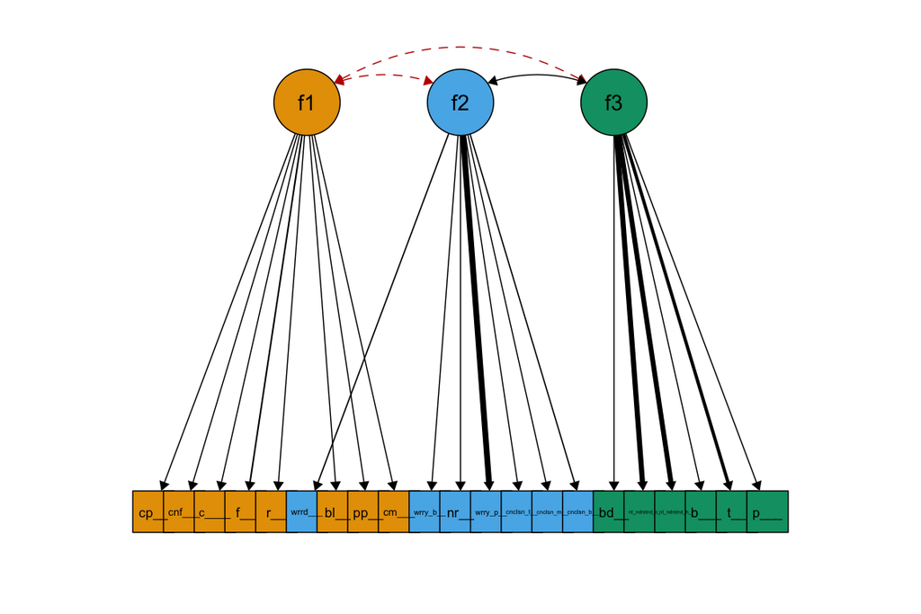

**Standardized Loading Across Folds**

| variable | mean | range | loading flag | heywood flag |
| --- | --- | --- | --- | --- |
| capable_person_b | 0.39 | 0.39 - 0.39 | 0 | 0 |
| confident_abt_future_b | 0.31 | 0.31 - 0.31 | 0 | 0 |
| comfortable_who_i_am_b | 0.50 | 0.50 - 0.50 | 0 | 0 |
| feel_smart_b | 0.59 | 0.59 - 0.59 | 0 | 0 |
| respect_lookup_b | 0.38 | 0.38 - 0.38 | 0 | 0 |
| worried_other_think_b | 0.58 | 0.58 - 0.58 | 0 | 0 |
| belong_school_b | 0.52 | 0.52 - 0.52 | 0 | 0 |
| people_accept_b | 0.46 | 0.46 - 0.46 | 0 | 0 |
| comfortable_at_school_b | 0.53 | 0.53 - 0.53 | 0 | 0 |
| worry_abt_dumb_b | 0.53 | 0.53 - 0.53 | 0 | 0 |
| nervous_worried_b | 0.43 | 0.43 - 0.43 | 0 | 0 |
| worry_ppl_dislike_b | 0.70 | 0.70 - 0.70 | 0 | 0 |
| conclusion_other_deaf_b | 0.53 | 0.53 - 0.53 | 0 | 0 |
| conclusion_my_perform_b | 0.55 | 0.55 - 0.55 | 0 | 0 |
| conclusion_abt_me_b | 0.58 | 0.58 - 0.58 | 0 | 0 |
| bad_grades_b | 0.55 | 0.55 - 0.55 | 0 | 0 |
| not_understand_class_b | 0.68 | 0.68 - 0.68 | 0 | 0 |
| not_understand_homework_b | 0.68 | 0.68 - 0.68 | 0 | 0 |
| bad_class_teacher_b | 0.57 | 0.57 - 0.57 | 0 | 0 |
| trouble_studying_b | 0.63 | 0.63 - 0.63 | 0 | 0 |
| pressure_parent_teacher_b | 0.49 | 0.49 - 0.49 | 0 | 0 |

Note: loadings flagged when < 0.3 in a fold. ‘heywood flag’ is the number of folds the variable’s estimated residual variance was negative

**Mean Factor Correlations**

|  | f1 | f2 | f3 | flag |
| --- | --- | --- | --- | --- |
| f1 | 1.00 |  |  | 0 |
| f2 | -0.05 | 1.00 |  | 0 |
| f3 | -0.16 | 0.57 | 1.00 | 0 |

Note: ‘flag’ is the number of folds the factor had a correlation > 0.9

**Scale Reliability Across Folds**

| factor | omega_h mean | omega_h range | omega_h flag | alpha mean | alpha range | alpha flag |
| --- | --- | --- | --- | --- | --- | --- |
| f1 | 0.67 | 0.67 - 0.67 | 0 | 0.67 | 0.67 - 0.67 | 0 |
| f2 | 0.76 | 0.76 - 0.76 | 0 | 0.77 | 0.77 - 0.77 | 0 |
| f3 | 0.77 | 0.77 - 0.77 | 0 | 0.78 | 0.78 - 0.78 | 0 |

Note: ‘flag’ is the number of folds the scale had a reliability < 0.6

# Appendix

## Within Fold Model Fit

| fold | 1-factor chisq.scaled | 1-factor df.scaled | 1-factor cfi.scaled | 1-factor rmsea.scaled | 2-factor chisq.scaled | 2-factor df.scaled | 2-factor cfi.scaled | 2-factor rmsea.scaled | 3-factor chisq.scaled | 3-factor df.scaled | 3-factor cfi.scaled | 3-factor rmsea.scaled |
| --- | --- | --- | --- | --- | --- | --- | --- | --- | --- | --- | --- | --- |
| 1 | 85.14 | 33.60 | 0.43 | 0.09 | 69.64 | 42.33 | 0.64 | 0.06 | 59.13 | 42.95 | 0.79 | 0.05 |
| 2 | 68.75 | 41.50 | 0.60 | 0.06 | 43.88 | 40.08 | 0.92 | 0.02 |  |  |  |  |
| Mean | 76.95 | 37.55 | 0.51 | 0.08 | 56.76 | 41.20 | 0.78 | 0.04 | 59.13 | 42.95 | 0.79 | 0.05 |

## All EFA Structures

### Factors: 1

**Factor Structure Option 1**

**In Folds: 1, 2**

f1 =~ capable_person_b + confident_abt_future_b + comfortable_who_i_am_b + feel_smart_b + respect_lookup_b + worried_other_think_b + belong_school_b + people_accept_b + comfortable_at_school_b + worry_abt_dumb_b + nervous_worried_b + worry_ppl_dislike_b + conclusion_other_deaf_b + conclusion_my_perform_b + conclusion_abt_me_b + bad_grades_b + not_understand_class_b + not_understand_homework_b + bad_class_teacher_b + trouble_studying_b + pressure_parent_teacher_b

### Factors: 2

**Factor Structure Option 1**

**In Folds: 1, 2**

f1 =~ capable_person_b + confident_abt_future_b + comfortable_who_i_am_b + feel_smart_b + respect_lookup_b + belong_school_b + people_accept_b + comfortable_at_school_b

f2 =~ worried_other_think_b + worry_abt_dumb_b + nervous_worried_b + worry_ppl_dislike_b + conclusion_other_deaf_b + conclusion_my_perform_b + conclusion_abt_me_b + bad_grades_b + not_understand_class_b + not_understand_homework_b + bad_class_teacher_b + trouble_studying_b + pressure_parent_teacher_b

### Factors: 3

**Factor Structure Option 1**

**In Folds: 1**

f1 =~ capable_person_b + confident_abt_future_b + comfortable_who_i_am_b + feel_smart_b + respect_lookup_b + belong_school_b + people_accept_b + comfortable_at_school_b

f2 =~ worried_other_think_b + worry_abt_dumb_b + nervous_worried_b + worry_ppl_dislike_b + conclusion_other_deaf_b + conclusion_my_perform_b + conclusion_abt_me_b

f3 =~ bad_grades_b + not_understand_class_b + not_understand_homework_b + bad_class_teacher_b + trouble_studying_b + pressure_parent_teacher_b

**Factor Structure Option 2**

**In Folds: 2**

f1 =~ capable_person_b + confident_abt_future_b + comfortable_who_i_am_b + feel_smart_b + respect_lookup_b + belong_school_b + people_accept_b + comfortable_at_school_b

f2 =~ worry_abt_dumb_b + nervous_worried_b + bad_grades_b + not_understand_class_b + not_understand_homework_b + bad_class_teacher_b + trouble_studying_b + pressure_parent_teacher_b

f3 =~ worried_other_think_b + worry_ppl_dislike_b + conclusion_other_deaf_b + conclusion_my_perform_b + conclusion_abt_me_b

### Factors: 4

**Factor Structure Option 1**

**In Folds: 1**

Structure contained single item factor

**Factor Structure Option 2**

**In Folds: 2**

f1 =~ capable_person_b + respect_lookup_b + belong_school_b + people_accept_b

f2 =~ confident_abt_future_b + comfortable_who_i_am_b + feel_smart_b + comfortable_at_school_b + worry_abt_dumb_b

f3 =~ worried_other_think_b + worry_ppl_dislike_b + conclusion_other_deaf_b + conclusion_my_perform_b + conclusion_abt_me_b

f4 =~ nervous_worried_b + bad_grades_b + not_understand_class_b + not_understand_homework_b + bad_class_teacher_b + trouble_studying_b + pressure_parent_teacher_b

### Factors: 5

**Factor Structure Option 1**

**In Folds: 1, 2**

Structure contained single item factor

### Factors: 6

**Factor Structure Option 1**

**In Folds: 1, 2**

Structure contained single item factor